# Chapter 2. Bohemia dataset

Sophie Donnet

2025-01-07

```r
library(ggplot2)
library(parallel)
library(viridis)
library(dplyr)
library(knitr)
library(readr)

require(abind)
require(mixtools)
require(parallel)


# Librairies --------------------------------------------------------------

library(tidyverse) # For data manipulation
library(GGally) # For ggpairs function
library(xtable) # To print teX tables
```

## 1. The Meadow vegetation data

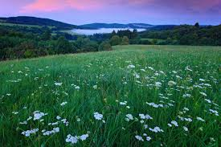

We consider the Data `data(ohrazeni)` from the R package `traitor`. This package is issued from the article “Community trait response to environment: disentangling species turnover vs intraspecific trait variability effects” by Lepš et al. (2011).

They study the vegetation composition in meadows of Bohemia, Czech Republic. Four specific traits, namely the specific leaf area (SLA), the leaf dry matter content (LDMC), the reproductive plant height and the seed weight are measured over 58 species . **Our objective is the identify groups of species that share similar traits**. An extract of the table corresponding to this dataset is provided here after.

In this dataset, we have removed the non numerical variables and the outliers (huge seed weight). The resulting dataset is in the file `Bohemia_vegetation.csv.`

```r
donnees <- read.table("Bohemia_vegetation.csv",
                      header = TRUE, sep = ",") %>%
  rename("Seed weight" = "Seed.weight")
kable(head(donnees))
```

| Species | SLA | LDMC | Height | Seed weight |
| --- | --- | --- | --- | --- |
| Sp1 | 28.3 | 275.9 | 60.5 | 0.0 |
| Sp2 | 27.7 | 294.3 | 39.5 | 0.1 |
| Sp3 | 23.8 | 227.4 | 105.0 | 0.2 |
| Sp4 | 30.4 | 166.2 | 45.0 | 1.3 |
| Sp5 | 28.4 | 187.4 | 75.0 | 0.7 |
| Sp6 | 23.3 | 322.0 | 27.5 | 0.5 |

We now plot de data.

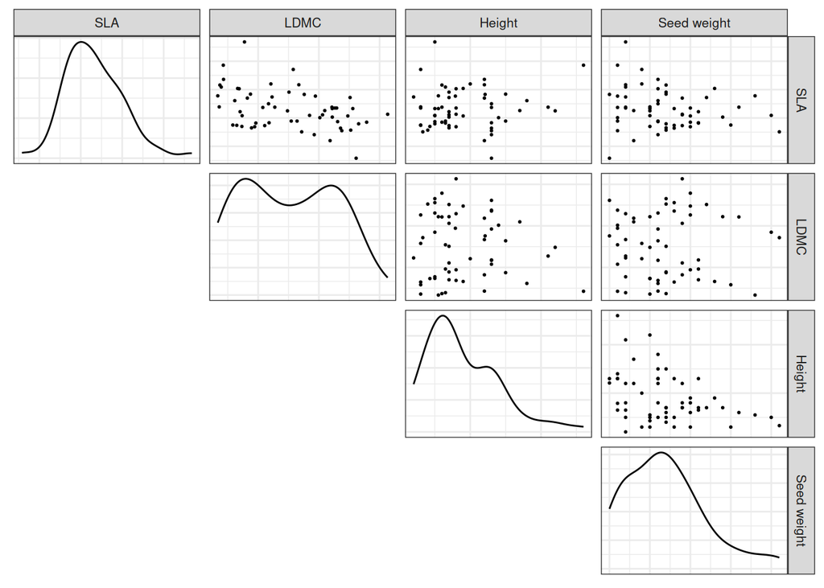

```r
# Descriptive figures -----------------------------------------------------
## Pair plot ---------------------------------------------------------------

pair_plot <- ggpairs(donnees %>% select_if(is.numeric), upper = list(continuous = wrap("points",
                                                          size = 1/.pt)), lower = "blank") +
  theme_bw() +
  theme(text = element_text(size = 10),
        axis.text = element_blank(),
        axis.ticks = element_blank())
pair_plot
```

## 2. EM algorithm for multivariate gaussian distributions

### 2.a Functions

The useful functions are in the file `utils_gaussian_mixture_functions.R`.

```r
source('utils_gaussian_mixture_functions.R')
ys <- read.table("Bohemia_vegetation.csv",
                 header = TRUE, row.names = 1, sep = ",") %>%   as.matrix()
```

### 2.b Run the EM

We now run the EM for several numbers of clusters and several intialisation points.

The code is the following one.

```r
get_best_estimate <- function(ks, ys, n_trys){
  purrr::map(ks, function(k){
    if(k == 1){
      all_res_k <- get_EM_estimation_mixture(ys = ys,
                                theta0 = list(pi = 1,
                                              mu = rep(0, ncol(ys)),
                                              Sigma = array(diag(1, ncol(ys)),
                                                            dim = c(ncol(ys), ncol(ys), 1))),
                                n_iter_max = 2000)
      return(c(all_res_k, k = k))
    }
    else{
      all_res_k <- mclapply(1:n_trys, function(i){
        set.seed(i)
        initial_theta <- get_theta0(k = k, ys = ys)
        all_res <- try(get_EM_estimation_mixture(ys = ys,
                                                 theta0 = initial_theta,
                                                 n_iter_max = 2000))
        if(inherits(all_res, "try-error")){
          return(NULL)
        }
        else{
          return(c(all_res, seed = i))
        }
      }, mc.cores = detectCores() - 2)
      lls <- map_dbl(all_res_k, function(x){
        if(is.null(x)){
          return(-Inf)
        }
        else{
          return(x$final_criterions$log_lik)
        }})
      return(c(all_res_k[[which.max(lls)]], k = k))
    }
  })
}
```

We obtain the estimate with the following code.

```r
gmm_est_multiple_ks <- get_best_estimate(1:6, ys, 200)
gmm_est_k3 <- mclapply(1:200, function(i){
  set.seed(i)
  initial_theta <- get_theta0(k = 3, ys = ys)
  all_res <- try(get_EM_estimation_mixture(ys = ys,
                                           theta0 = initial_theta,
                                           n_iter_max = 2000))
  if(inherits(all_res, "try-error")){
    return(NULL)
  }
  else{
    return(c(all_res, seed = i))
  }
}, mc.cores = detectCores() - 2)
gmm_est_best <- map_dbl(gmm_est_k3, function(x){
  if(is.null(x))
    return(-Inf)
  else
    return(x$final_criterions$log_lik)
}) %>%
  which.max() %>%
  gmm_est_k3[[.]]

save(list = ls(pattern = "gmm_est"),
     file = "gmm_est.RData")
```

## 3. Results

### 3.a Influence of the starting point

First, we illustrate an important feature of the EM algorithm which is the influence of the starting parameter $\theta^{(0)}$. For $K = 3$, we chose randomly $200$ different starting points and run the subsequent algorithms. The log-likelihood is monitored through the algorithm, and the algorithm stops when the increase in the log-likelihood becomes lower than $10^{-8}$. The following figure shows the differences in the final log-likelihood, therefore illustrating the numbers of local maxima.

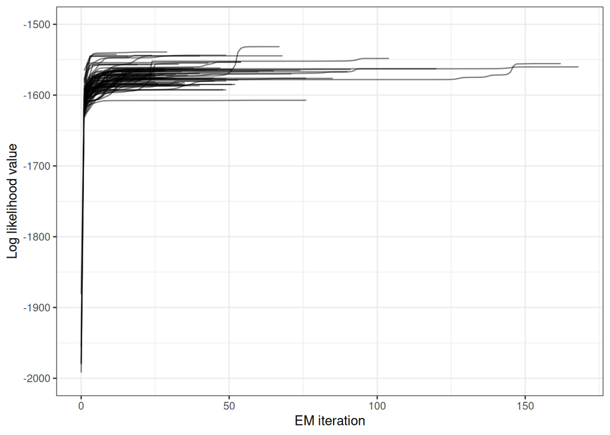

```r
likelihoods_plot <- map(gmm_est_k3, "log_likelihoods") %>%
  map_dfr(function(x){
    if(is.null(x)){
      return(NULL)
    }
    else{
      n_iter <- length(x) - 1
      return(data.frame(iteration = 0:n_iter,
                        log_lik = 2 * x * nrow(donnees)))
    }
  }, .id = "Replicate") %>%
  ggplot() +
  aes(x = iteration, y = log_lik, group = Replicate) +
  geom_line(alpha = .5) +
  theme_bw() +
  lims(y = c(-2000, -1500)) +
  labs(x = "EM iteration", y = "Log likelihood value")
likelihoods_plot
```

It is worth noting that this is not a problem , as one can run (in parallel) the algorithm from multiple starting points, and choose the best with respect to the likelihood. . This however illustrates the difficulty to find a global maxima of the likelihood in complex settings.

### 3.b Choosing the number of components.}

The previous procedure was performed for $K\in \lbrace 1,\dots, 6\rbrace$, and choosing the bet final point among the 200 trials.  
For the 6 models, we compute the 3 model selection criterion discussed in the course (AIC, BIC, ICL), together with the negative log-likelihood.

| k | log_lik | AIC | BIC | ICL |
| --- | --- | --- | --- | --- |
| -1 | -1656.045 | -1684.045 | -1712.891 | -1712.891 |
| -2 | -1598.695 | -1656.695 | -1716.448 | -1730.783 |
| -3 | -1531.577 | -1619.577 | -1710.236 | -1715.665 |
| -4 | -1471.263 | -1589.263 | -1710.829 | -1713.910 |
| -5 | -1442.812 | -1590.812 | -1743.285 | -1748.982 |
| -6 | -1422.497 | -1600.497 | -1783.877 | -1788.049 |

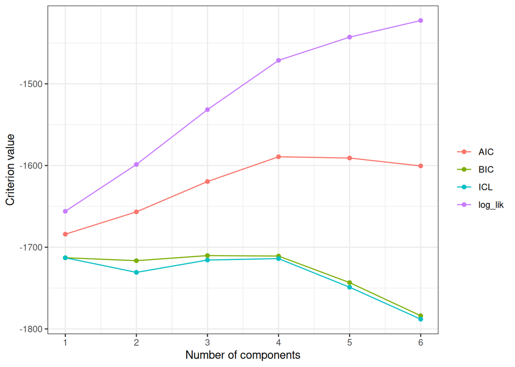

```r
criterions_plot <- map_dfr(gmm_est_multiple_ks, "final_criterions") %>%
  mutate(log_lik = - 2 * log_lik) %>%
  pivot_longer(-k) %>%
  ggplot() +
  aes(x = k, y = -value, color = name) +
  geom_line() +
  geom_point() +
  scale_x_continuous(breaks = 1:6) +
  theme_bw() +
  labs(x = "Number of components",
       y = "Criterion value",
       color =  "")
criterions_plot
```

### 3.c Clustering results.

For $K = 3$, the best parameter is chosen. We are then able to cluster the observations.

```r
estimated_clusters <- gmm_est_best$posterior_weights %>%
  apply(1, which.max) %>%
  factor()
ClusterTable <- as.data.frame(table(estimated_clusters))
kable(ClusterTable)
```

| estimated_clusters | Freq |
| --- | --- |
| 1 | 15 |
| 2 | 28 |
| 3 | 15 |

The three clusters red green blue gather respectively 15, 28, 15 observations We plot the distributions of the variables inside each cluster.

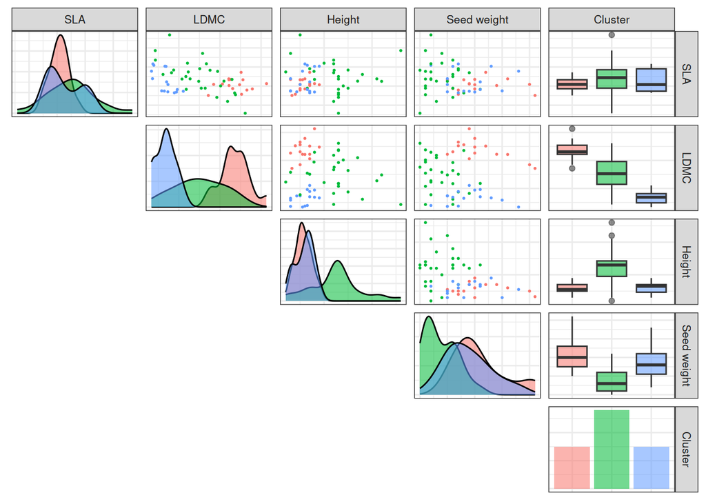

```r
cluster_pair_plot <- ggpairs(donnees %>%
                       select_if(is.numeric) %>%
                       mutate(Cluster = estimated_clusters),
                     mapping = aes(color = Cluster, alpha = 1),
                     upper = list(continuous = wrap("points", alpha = 1,
                                                    size = 1/.pt)),
                     lower = "blank") +
  theme_bw() +
  theme(text = element_text(size = 10),
        axis.text = element_blank(),
        axis.ticks = element_blank())
cluster_pair_plot
```

It can be interesting to compare the clusterings obtained with $K=3$ and $K=4$

```r
gmm_est_k4 <- gmm_est_multiple_ks[[4]]
estimated_clusters_k4 <- gmm_est_k4$posterior_weights %>%
  apply(1, which.max) %>%
  factor()
Table_compare_cluster <- table(estimated_clusters_k4,estimated_clusters)
rownames(Table_compare_cluster)=c(1:4)
kable(Table_compare_cluster)
```

| 1 | 2 | 3 |
| --- | --- | --- |
| 0 | 0 | 15 |
| 1 | 28 | 0 |
| 6 | 0 | 0 |
| 8 | 0 | 0 |

## References

Lepš, Jan, Francesco de Bello, Petr Šmilauer, and Jiřı́ Doležal. 2011. “Community Trait Response to Environment: Disentangling Species Turnover Vs Intraspecific Trait Variability Effects.” *Ecography* 34 (5): 856–63.